# RDA_model_within-population_and_evolutionary_responses_Ppinaster_study

Thomas Francisco

2025-07-22

```r
library(vegan)
library(dplyr)
library(robust)
library(qvalue)
library(rgdal)
library(sf)
library(terra)
library(ggplot2)
library(radiant.data)
library(textshape)
library(rnaturalearth)
library(scales)
library(raster)
library(corrplot)
library(writexl)
library(ggspatial)
library(vcfR)
library(stringr)
library(dismo)
library(grid)
```

This script investigates the within-population variability in genomic composition at climate-associated loci, as well as potential evolutionary responses to climate change across cohorts.

First, we built a GEA model using the genomic data across the 82 populations covering the species range and the climatic conditions for each of these populations for the retained climatic predictors during the 1901-1950 time period (past). This model was used to model the relationship between climate associated loci and the climatic predictors, as well as to predict the optimal genomic composition for different time periods across Lacanau and Tocchi populations:  
- Historical (Mid-Holocene, approximately 6,000 years ago)  
- Present (1991-2020)  
- Future (2041-2070)

Finally, we transformed the genomic data at climate-associated loci of each individual in these two populations to RDA values and plotted then in this space along with optimal predicted values. Student t-test were performed to compare the mean genomic composition at climate associated loci across cohorts to detect potential evolutionary responses.

# 1 Data

```r
load("Data/Chapter3/Pinus_pinaster/GEA_model_pinaster/Population/meta_data_pop_final.Rdata")
#Alphabetic order
meta_data_pop_order <- meta_data_pop_final[order(meta_data_pop_final$Population_ID),]
identical(meta_data_pop_order$Population_ID,meta_data_pop_final$Population_ID)
```

```
## [1] TRUE
```

## 1.1 Past/present and future climatic data

```r
#climatic/structure/IBD data
load("Data/Chapter3/Pinus_pinaster/GEA_model_pinaster/GEA/variance_partitioning/Climatic_data_RDA_pRDA.Rdata")
```

Here we will also load the raster data not scaled but with the mean and sd values of the past climatic data to scaled the data together following Capblancq & Forester (2021).

```r
list_models_clim<- c("GFDL_ESM4","IPSL_CM6A_LR","MPI_ESM1_2_HR","MRI_ESM2_0","UKESM1_0_LL")

#Load past and future raster data
climatic_variables_to_keep <-c("bio1", "bio12", "bio15","bio3","bio4","SHM") #Subset of retained clim var, see script processing clim data
list_raster <- c("past_climatic_data_raster")#,"present_climatic_data_raster","future_climatic_data_raster"

for(i in 1:length(list_models_clim)){

  model <- list_models_clim[i]

for(x in 1:length(list_raster)){
  name <- c("past")#,"present","future"
  name_clim <- name[x]#name final raster
  var <- list_raster[x]#name of the raster

  if(var == "future_climatic_data_raster"){
    var= paste0("future_climatic_data_raster_",model)

    load(paste0("Data/Chapter3/Pinus_pinaster/GEA_model_pinaster/Genomic_offset/RDA/",var,".Rdata")) #Load data
  raster_clim <- get(var)[[climatic_variables_to_keep]]#Keep only var in clim_variables to keep
  names(raster_clim)=c("Annual_Tc","Annual_P","P_Seasonality","Isothermality","Tc_Seasonality","Summer_aridity") #Change the name to match the names of the scaled and center values
  assign(paste0("raster_",name_clim,"_clim_",model),raster_clim)
  } else {
    load(paste0("Data/Chapter3/Pinus_pinaster/GEA_model_pinaster/Genomic_offset/RDA/",var,".Rdata")) #Load data
  raster_clim <- get(var)[[climatic_variables_to_keep]]#Keep only var in clim_variables to keep
  names(raster_clim)=c("Annual_Tc","Annual_P","P_Seasonality","Isothermality","Tc_Seasonality","Summer_aridity") #Change the name to match the names of the scaled and center values
  assign(paste0("raster_",name_clim,"_clim"),raster_clim)
   }
  }
}
```

We also need the scale and center values for the reference period (past):

```r
load("Data/Chapter3/Pinus_pinaster/GEA_model_pinaster/Climatic_data/scale_env_value_cli.Rdata")
load("Data/Chapter3/Pinus_pinaster/GEA_model_pinaster/Climatic_data/center_env_value_cli.Rdata")
```

```r
list_name <- c("past")#,"present","future"
coords <- data.frame(apply(meta_data_pop_order[,c(5:4)], 2, as.numeric))#Longitude then latitude

for(i in 1:length(list_models_clim)){

  model <- list_models_clim[i]

for(x in 1: length(list_name)){

  name <- list_name[x]

  if(name == "future"){

  raster_data <- get(paste0("raster_",name,"_clim_",model))

  clim_data <- raster::extract(raster_data, coords)
    clim_data_order <- data.frame(clim_data[,c(1,4,5,2,3,6)])#Put it in the same order as center_env and scale object
  #Standardisation of the environmental variables
  clim_data_scale <- as.data.frame(scale(clim_data_order, center=center_env_value_cli, scale=scale_env_value_cli))
  assign(paste0("clim_df_",name,"_scale_",model),clim_data_scale)
  } else {

   raster_data <- get(paste0("raster_",name,"_clim"))

  clim_data <- raster::extract(raster_data, coords)
    clim_data_order <- data.frame(clim_data[,c(1,4,5,2,3,6)])#Same order as well
  #Standardisation of the environmental variables
  clim_data_scale <- as.data.frame(scale(clim_data_order, center=center_env_value_cli, scale=scale_env_value_cli))

  assign(paste0("clim_df_",name,"_scale"),clim_data_scale)
    }
  }
}
```

## 1.2 Genomic data

The genomic data were corrected using a more stringent MAC correction for the 82 populations. There was an issue with the genotypes in the VCF file. Therefore, we need to recompute the allele frequencies for the 82 populations so that they match the genotypes used in the Lacanau and Tocchi datasets.

```r
#genomic data
load("Data/Chapter3/Pinus_pinaster/GEA_model_pinaster/Genomic_data/good_genotyped_comparison_LAC_TOC/data_allelic_frequencies_82pop_pinaster_9636_1518.Rdata")

colnames(data_allelic_frequencies_82pop_pinaster_9636_1518) <- sub("_.*", "", colnames(data_allelic_frequencies_82pop_pinaster_9636_1518))
genomic_matrix <- data_allelic_frequencies_82pop_pinaster_9636_1518
```

### 1.2.1 Outliers sets

We computed the GEA models using four different set of SNPs to visualise the impact of the SNP sets on the GEA model.

#### 1.2.1.1 Less conservative thresholds

```r
#set of less conservative thresholds
load("Results/Chapter3/Pinaster/GEA_model_pinaster/GEA/outliers/set/outliers_set_LC_common.Rdata")
```

#### 1.2.1.2 More conservative thresholds

```r
load("Results/Chapter3/Pinaster/GEA_model_pinaster/GEA/outliers/set/outliers_set_MC_common.Rdata")
```

#### 1.2.1.3 all outliers

```r
load("Results/Chapter3/Pinaster/GEA_model_pinaster/GEA/outliers/set/all_outliers_set_LC_common.Rdata")
all_outliers_set_LC_common_unique <- all_outliers_set_LC_common %>% unique()
load("Results/Chapter3/Pinaster/GEA_model_pinaster/GEA/outliers/set/all_outliers_set_MC_common.Rdata")
all_outliers_set_MC_common_unique <- all_outliers_set_MC_common %>% unique()
```

We also need to load 45 SNPs that seem not to match between the two datasets and that should therefore be removed just in case.

```r
SNPs_to_remove_45 <- read.table("Results/all_species/Genetic_load/Issue_polarisation/Pinaster_secondVCF/snp_non_matching_REF_ALT_to_remove.txt",h=T)

#Reformate
SNPs_to_remove_45$x <- sub("-", "", SNPs_to_remove_45$x)
#Apply it to all outlier LC
all_outliers_set_LC_common_unique_final <- all_outliers_set_LC_common_unique[ ! all_outliers_set_LC_common_unique %in% SNPs_to_remove_45$x ]

#All MC
all_outliers_set_MC_common_unique_final <- all_outliers_set_MC_common_unique[ ! all_outliers_set_MC_common_unique %in% SNPs_to_remove_45$x ]

#LC
outliers_set_LC_common_final <- outliers_set_LC_common[ ! outliers_set_LC_common %in% SNPs_to_remove_45$x ]

#MC
outliers_set_MC_common_final <- outliers_set_MC_common[ ! outliers_set_MC_common %in% SNPs_to_remove_45$x ]
```

# 2 Calculation of the GEA relationship

## 2.1 Models

### 2.1.1 Less conservative outlier set (LC)

RDA model built with all the climate-associated SNPs identified by at least two GEA methods and using the less conservative thresholds for identification: FDR 10%, top 5% and Bayes factor < 8; see explanations on the README file about the climate-associated SNPs identification.

```r
RDA_outliers_LC <- rda(formula = genomic_matrix[outliers_set_LC_common_final] ~  Annual_Tc+Isothermality+Tc_Seasonality+Annual_P+P_Seasonality+Summer_aridity, data = Climatic_data_RDA_pRDA, scale=F)

RsquareAdj(RDA_outliers_LC)
```

```
## $r.squared
## [1] 0.4163684
##
## $adj.r.squared
## [1] 0.3696779
```

### 2.1.2 More conservative outlier set (MC)

RDA model built with climate-associated SNPs identified by at least two GEA methods and using the more conservative thresholds for identification: FDR 5%, top 1% and Bayes factor < 10; see also explanations on the README file about the climate-associated SNPs identification.

```r
RDA_outliers_MC <- rda(formula = genomic_matrix[outliers_set_MC_common_final] ~  Annual_Tc+Isothermality+Tc_Seasonality+Annual_P+P_Seasonality+Summer_aridity, data = Climatic_data_RDA_pRDA, scale=F)

RsquareAdj(RDA_outliers_MC)
```

```
## $r.squared
## [1] 0.445787
##
## $adj.r.squared
## [1] 0.40145
```

### 2.1.3 All outliers set LC

RDA model built with all the climate-associated SNPs identified using the less conservative thresholds.

```r
RDA_all_outliers_LC <- rda(formula = genomic_matrix[all_outliers_set_LC_common_unique_final] ~  Annual_Tc+Isothermality+Tc_Seasonality+Annual_P+P_Seasonality+Summer_aridity, data = Climatic_data_RDA_pRDA, scale=F)

RsquareAdj(RDA_all_outliers_LC)
```

```
## $r.squared
## [1] 0.3651993
##
## $adj.r.squared
## [1] 0.3144153
```

### 2.1.4 All outliers set MC

RDA model built with all the climate-associated SNPs identified using the more conservative thresholds.

```r
RDA_all_outliers_MC <- rda(formula = genomic_matrix[all_outliers_set_MC_common_unique_final] ~  Annual_Tc+Isothermality+Tc_Seasonality+Annual_P+P_Seasonality+Summer_aridity, data = Climatic_data_RDA_pRDA, scale=F)

RsquareAdj(RDA_all_outliers_MC)
```

```
## $r.squared
## [1] 0.376991
##
## $adj.r.squared
## [1] 0.3271503
```

We can save the models to used them later for comparison:

```r
list_models <- c("RDA_outliers_LC","RDA_outliers_MC","RDA_all_outliers_LC","RDA_all_outliers_MC")

for(x in 1:length(list_models)){

  name_model<- list_models[x]
  file_save<- get(name_model)
  name <- paste0("model_GEA_",name_model)
  assign(name,file_save)
  save(list = paste0("model_GEA_",name_model),file=paste0("Results/Chapter3/Pinaster/GEA_model_pinaster/Genomic_offset/RDA/data/models/",name,".Rdata"))
}
```

All further analysis will be performed on the different climate-associated sets to investigate whether we observe the same patterns regardless of the SNP sets:

```r
list_outliers_set <- c("outliers_set_LC_common_final","outliers_set_MC_common_final","all_outliers_set_LC_common_unique_final","all_outliers_set_MC_common_unique_final")
list_RDA <- c("RDA_outliers_LC","RDA_outliers_MC","RDA_all_outliers_LC","RDA_all_outliers_MC")
```

## 2.2 Graphical visualisation

We can plot the explained variance along the RDA axes and the climatic variables:

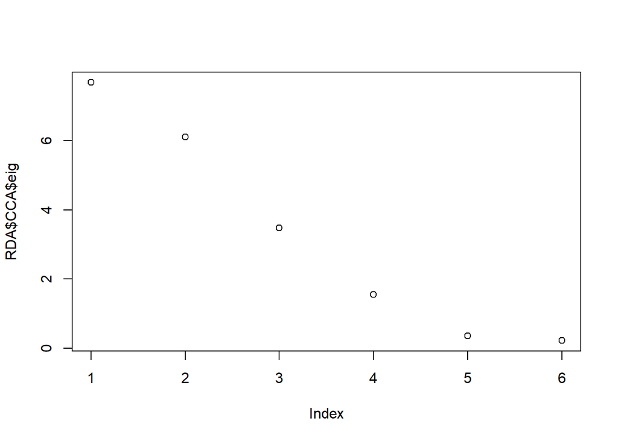

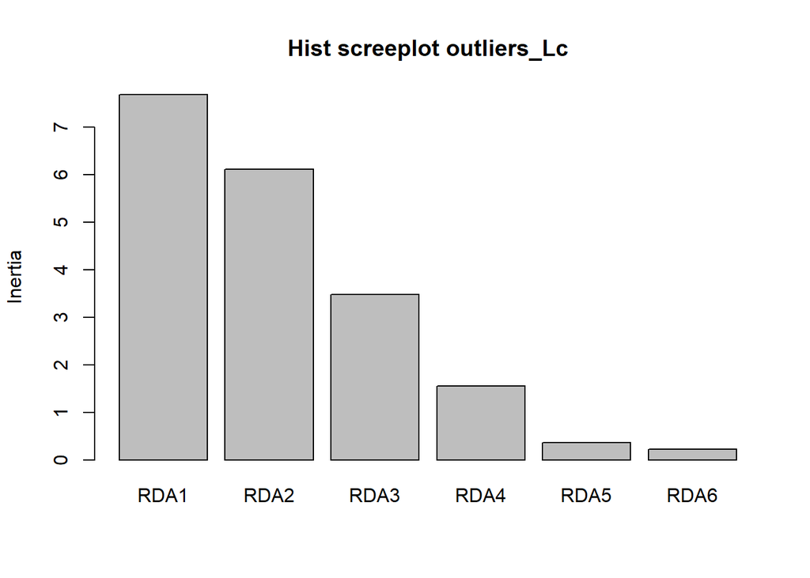

```
##      RDA1      RDA2      RDA3      RDA4      RDA5      RDA6
## 39.592624 31.496103 17.906356  8.017358  1.838886  1.148672
```

```r
for(x in 1: length(list_RDA)){
  RDA <- get(list_RDA[x])
  name <- c("outliers_LC","Outliers_MC","all_outliers_LC","all_outliers_MC")
  #Screeplot
plot(RDA$CCA$eig, option="screeplot")

#In histogram
screeplot_RDA <- screeplot(RDA,main = paste0("Hist screeplot ",name[x]))

#Explained variance along each RDA axis
explain_variance <-RDA$CCA$eig*100/sum(RDA$CCA$eig)

assign(paste0("explain_variance",name[x]),explain_variance)

  print(get(paste0("explain_variance",name[x])))
#Save
pdf(paste0("Results/Chapter3/Pinaster/GEA_model_pinaster/Genomic_offset/RDA/figures/screeplot/Screeplot_RDA_",name[x],".pdf"));screeplot(RDA,main = paste0("Hist screeplot ",name[x]));dev.off()
}
```

We can see that the first two RDA axes appear to explain most of the genetic variation across populations. We will use these two axes for further analysis of each SNP set.

We can also plot the loci and climatic variables in the RDA space to visualise their relationships:

[figure not shown]

```r
for(x in 1:length(list_RDA)){

  RDA <- get(list_RDA[x])
  name <- c("outliers_LC","Outliers_MC","all_outliers_LC","all_outliers_MC")

  score_loci <- as.data.frame(scores(RDA, choices=c(1:2), display="species", scaling="none"))
score_climatic_var <- as.data.frame(scores(RDA, choices=c(1:2), display="bp"))
explained_variance_round <- round(RDA$CCA$eig*100/sum(RDA$CCA$eig),digits=1)

#Biplot with SNPs and climatic variables along the two first RDA axis.
 biplot_outliers_RDA<- ggplot() +
  geom_hline(yintercept=0, linetype="dashed", color = gray(.80), size=0.6) +
  geom_vline(xintercept=0, linetype="dashed", color = gray(.80), size=0.6) +
  geom_point(data = score_loci, aes(x=RDA1*15, y=RDA2*15,color="locus"), size = 1.4) +
  geom_segment(data = score_climatic_var, aes(xend=RDA1, yend=RDA2, x=0, y=0), colour="black", size=0.15, linetype=1, arrow=arrow(length = unit(0.02, "npc"))) +
  geom_text(data = score_climatic_var, aes(x=1.1*RDA1, y=1.1*RDA2, label = row.names(score_climatic_var)), size = 2.5) +
  xlab(paste0("RDA 1 (",explained_variance_round[1],"%)")) +
  ylab(paste0("RDA 2 (",explained_variance_round[2],"%)")) +
   ggtitle(paste0("Biplot RDA ",name[x])) +
  guides(color=guide_legend(title="Locus type")) +
  scale_color_manual(values ="#F9A242FF") +
  theme_bw(base_size = 11) +
  theme(legend.position="right", panel.grid = element_blank(), strip.text = element_text(size=11),plot.title = element_text(hjust = 0.5,color = "Black",face="italic"))

 print(biplot_outliers_RDA)

#Save plots
pdf(paste0("Results/Chapter3/Pinaster/GEA_model_pinaster/Genomic_offset/RDA/figures/biplot/biplot_outliers_RDA_",name[x],".pdf"));print(biplot_outliers_RDA);dev.off()
}
```

We can plot the populations in this space to see if their distribution matches the expected climatic pattern. Here, the population positions represent observed values rather than predicted ones.

[figure not shown]

```r
for(x in 1:length(list_RDA)){
  RDA <- get(list_RDA[x])
  name <- c("outliers_LC","Outliers_MC","all_outliers_LC","all_outliers_MC")

#Score along the 2 first RDA axis
score_climatic_var <- as.data.frame(scores(RDA, choices=c(1:2), display="bp"))
#Score_population <- data.frame(RDA$CCA$u[,c(1,2)]) #predicted population scores
observed_scores_populations <- as.data.frame(scores(RDA,choices=c(1,2), display = "sites",scaling="none"))

#Explained variance
explained_variance_round <- round(RDA$CCA$eig*100/sum(RDA$CCA$eig),digits=1)

#Merge for country info
Score_population_bis <- rownames_to_column(observed_scores_populations,"Population_ID")
score_with_country_info <- merge(Score_population_bis,meta_data_pop_order[,c(1,3)],"Population_ID")
score_with_country_info$Country <- as.factor(score_with_country_info$Country)

group_palette <- c("ALG"="orangered3","ESP"= "darkorchid3", "FRA"="navyblue", "MAR"="turquoise2", "PRT"="orange", "TUN"="darkgreen")

#Biplot with populations and climatic variables along the 2 first RDA axis
biplot_populations <- ggplot() +
  geom_hline(yintercept = 0, linetype = "dashed", color = gray(0.80), size = 0.6) +
  geom_vline(xintercept = 0, linetype = "dashed", color = gray(0.80), size = 0.6) +
  geom_point(data = score_with_country_info, aes(x = RDA1 * 3, y = RDA2 * 3, colour = Country), size = 2, alpha = 0.8) +
  geom_segment(data = score_climatic_var, aes(xend = RDA1, yend = RDA2, x = 0, y = 0), colour = "black", size = 0.15, linetype = 1, arrow = arrow(length = unit(0.02, "npc"))) +
  geom_text(data = score_climatic_var, aes(x=1.1*RDA1, y=1.1*RDA2, label = row.names(score_climatic_var)), size = 2.5)+
  xlab(paste0("RDA 1 (",explained_variance_round[1],"%)")) +
  ylab(paste0("RDA 2 (",explained_variance_round[2],"%)")) +
  ggtitle(paste0("Biplot RDA Populations ",name[x])) +
  scale_color_manual(name = "Countries", values = group_palette, labels = levels(score_with_country_info$Country)) +
  theme_bw(base_size = 11) +
  theme(legend.position="right", panel.grid = element_blank(), strip.text = element_text(size=11),plot.title = element_text(hjust = 0.5,color = "Black",face="italic"))+
  labs(color = "Country")

 print(biplot_populations)

#Save plots
pdf(paste0("Results/Chapter3/Pinaster/GEA_model_pinaster/Genomic_offset/RDA/figures/biplot/biplot_population_RDA_",name[x],".pdf"));print(biplot_populations);dev.off()
}
```

# 3 Historical climatic data

```r
meta_data_plots <- read.csv("Data/Chapter3/Pinus_pinaster/CGs/Metadata_Lac-Toc.csv",h=T,sep=";",dec=",")
```

First, we need to load the climatic variables and compute the BIO variables, and then add the SHM:

```r
#LIG
#load("Data/Chapter3/Pinus_pinaster/Historical_climate/LIG/prec_cropped_format_biovar.Rdata")
#load("Data/Chapter3/Pinus_pinaster/Historical_climate/LIG/tmin_cropped_format_biovar.Rdata")
#load("Data/Chapter3/Pinus_pinaster/Historical_climate/LIG/tmax_cropped_format_biovar.Rdata")
#prec_cropped_format_biovar_LIG <- prec_cropped_format_biovar
#tmin_cropped_format_biovar_LIG <- tmin_cropped_format_biovar
#tmax_cropped_format_biovar_LIG <- tmax_cropped_format_biovar

#prec_cropped_format_biovar_LIG <- stack("Data/Chapter3/Pinus_pinaster/Historical_climate/LIG/prec_cropped_format_biovar.tif")
#tmin_cropped_format_biovar_LIG <- stack("Data/Chapter3/Pinus_pinaster/Historical_climate/LIG/tmin_cropped_format_biovar.tif")
#tmax_cropped_format_biovar_LIG <- stack("Data/Chapter3/Pinus_pinaster/Historical_climate/LIG/tmax_cropped_format_biovar.tif")

#load("Data/Chapter3/Pinus_pinaster/Historical_climate/LIG/SHM_LIG.Rdata")

#MH6000
#load("Data/Chapter3/Pinus_pinaster/Historical_climate/Mid_Holo_6000/prec_cropped_format_biovar_Mid_Holo_6000.Rdata")
#load("Data/Chapter3/Pinus_pinaster/Historical_climate/Mid_Holo_6000/tmin_cropped_format_biovar_Mid_Holo_6000.Rdata")
#load("Data/Chapter3/Pinus_pinaster/Historical_climate/Mid_Holo_6000/tmax_cropped_format_biovar_Mid_Holo_6000.Rdata")

list_models<- c("MIROC_ESM","IPSL_CM5A_LR","MPI_ESM_P","MRI_CGCM3","CNRM_CM5")

for(x in 1:length(list_models)){

  model <- list_models[x]

prec_cropped_format_biovar_Mid_Holo_6000 <- stack(paste0("Data/Chapter3/Pinus_pinaster/Historical_climate/Mid_Holo_6000_models/prec/prec_cropped_format_biovar_Mid_Holo_6000_",model,".tif"))
assign(paste0("prec_cropped_format_biovar_Mid_Holo_6000_",model),prec_cropped_format_biovar_Mid_Holo_6000)

tmin_cropped_format_biovar_Mid_Holo_6000 <- stack(paste0("Data/Chapter3/Pinus_pinaster/Historical_climate/Mid_Holo_6000_models/tmin/tmin_cropped_format_biovar_Mid_Holo_6000_",model,".tif"))
assign(paste0("tmin_cropped_format_biovar_Mid_Holo_6000_",model),tmin_cropped_format_biovar_Mid_Holo_6000)

tmax_cropped_format_biovar_Mid_Holo_6000 <- stack(paste0("Data/Chapter3/Pinus_pinaster/Historical_climate/Mid_Holo_6000_models/tmax/tmax_cropped_format_biovar_Mid_Holo_6000_",model,".tif"))
assign(paste0("tmax_cropped_format_biovar_Mid_Holo_6000_",model),tmax_cropped_format_biovar_Mid_Holo_6000)

load(paste0("Data/Chapter3/Pinus_pinaster/Historical_climate/Mid_Holo_6000_models/SHM/SHM_MH_6000_",model,".Rdata"))
}
```

Extract the climate for the two populations:

```r
list_name <- c("Mid_Holo_6000_MIROC_ESM","Mid_Holo_6000_IPSL_CM5A_LR","Mid_Holo_6000_MPI_ESM_P","Mid_Holo_6000_MRI_CGCM3","Mid_Holo_6000_CNRM_CM5")#"LIG",
list_name_bis <- c("MH_6000_MIROC_ESM","MH_6000_IPSL_CM5A_LR","MH_6000_MPI_ESM_P","MH_6000_MRI_CGCM3","MH_6000_CNRM_CM5")#"LIG",
coords <- data.frame(apply(meta_data_plots[,c(2:3)], 2, as.numeric))#Longitude then latitude

for(x in 1: length(list_name)){

  name <- list_name[x]
  name_bis <- list_name_bis[x]

  prec_raster <- get(paste0("prec_cropped_format_biovar_",name))
  tmin_raster <- get(paste0("tmin_cropped_format_biovar_",name))
  tmax_raster <- get(paste0("tmax_cropped_format_biovar_",name))

  prec_data <- raster::extract(prec_raster, coords)
  tmin_data <- raster::extract(tmin_raster, coords)
  tmax_data <- raster::extract(tmax_raster, coords)

  bioclim_var <- biovars(prec_data,tmin_data,tmax_data)

  #SHM
  SHM_data <- get(paste0("SHM_",name_bis))

  SHM_extraction <- raster::extract(SHM_data, coords)

  df_clim_data <- data.frame(bioclim_var[,c(1,3,4,12,15)],SHM=SHM_extraction)
  colnames(df_clim_data) <- c("Annual_Tc","Isothermality","Tc_Seasonality","Annual_P","P_Seasonality","Summer_aridity")

  assign(paste0("clim_df_",name,"_nonscaled_plots"),df_clim_data)

  #Scaled
  clim_data_scale <- as.data.frame(scale(df_clim_data, center=center_env_value_cli, scale=scale_env_value_cli))
  assign(paste0("clim_df_",name,"_scale_plots"),clim_data_scale)
}
```